# **Happiness Levels and Alcohol Consumption - Shiny**

Pranavi Shekhar

31/07/2020

## **About the App**

This app uses the *Happiness and Alcohol Consumption* data set obtained from **Kaggle** to build a linear regression model for observing the average happiness score of individuals across 122 countries, as a function of consumption of different alcoholic beverages as well as the Human Development Index(HDI).

The plots created are not particularly useful for making predictions, but can be used for observing and understanding the trends in and the structure of the data set.

## **Viewing the Data**

- The app has a **Data** tab in which users can take a look at the data set. A description of the data is also available in the side bar.
- The user can choose the range of rows to display via a slider. For instance, setting the range as 2-30 will display the rows numbered 2-30. The data set contains a maximum of 122 rows.
- There is an option to filter the data by *Region* or *Hemisphere*. Selecting this will show only entries in the *Region*/*Hemisphere* specified.
- The user can also select the range of happiness scores they wish to view using the slider given. The maximum score is 7.526 and minimum is 3.069 (out of 10).

## **Viewing the Plot**

- All the plots generated are based on Plotly and can be viewed in the **Plots** tab.
- The X axis of the plots can be either one of three alcoholic beverages - Beer, Spirits or Wine - or the Human Development Index (HDI). The plot basically shows the dependence of happiness score on the selected X Axis metric.
- Each plot can be **categorized** based on *Region* or *Hemisphere*. This can be selected in the *Group points By* section. This results in the points being colored by the region/hemisphere they belong to. Selecting *None* in the *Group points By* section gives a basic, **un-categorized** plot.
- In the **un-categorized** plot, we can **Select** any group of points and obtain a linear regression model, with a slope and intercept, for the selected points. The slope and intercept will be displayed on the side bar.
- For plots **categorized** by region/hemisphere the category-wise regression lines are automatically plotted. **Hovering** over any line/point shows the corresponding slope and intercept for that particular region/hemisphere.
- Display of the lines and the legend entries can be toggled using the relevant check boxes. For viewing specific groups of points/lines, Plotly’s interactive interface can be taken advantage of (double-clicking the legend entries isolates points, selecting a line isolates it).
- Selection is not valid for categorized plots and hovering does not produce any results for un-categorized plots as it has no meaning.

## **Application Screenshots**

#### **1. Viewing the Data**

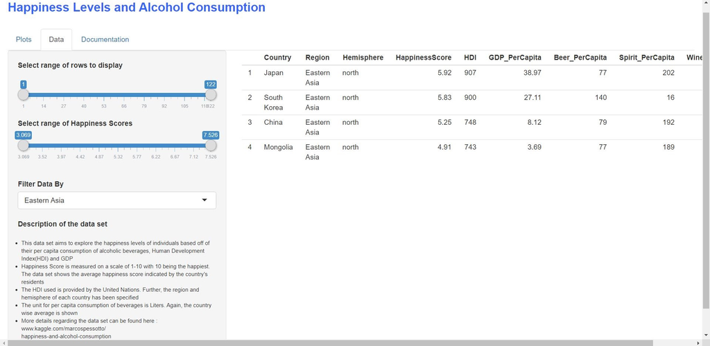

#### **2. Un-Categorized Plot**

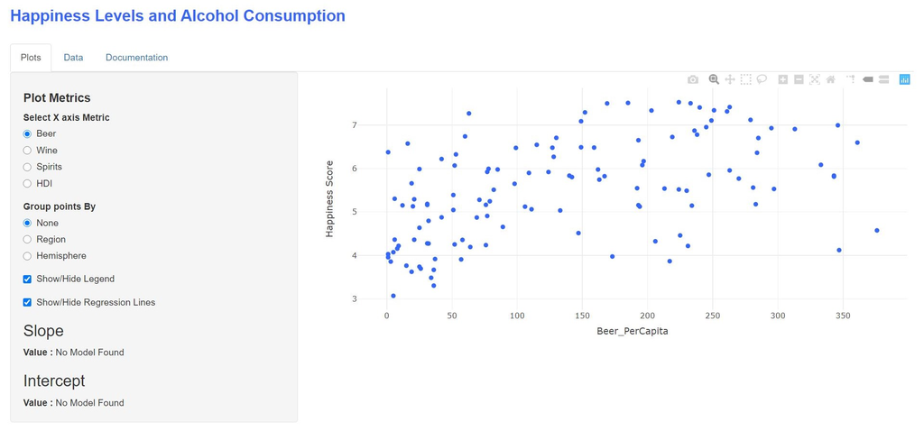

#### **3. Regression Line for** *Selected* **points (selected using Box Select)**

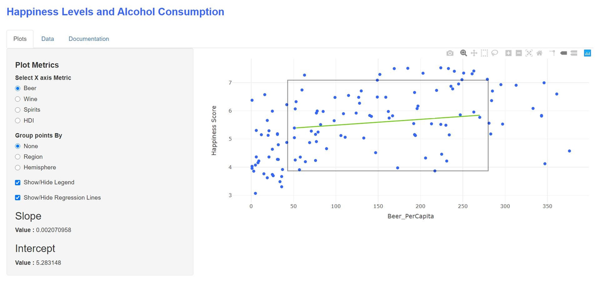

#### **4. Categorized Plot**

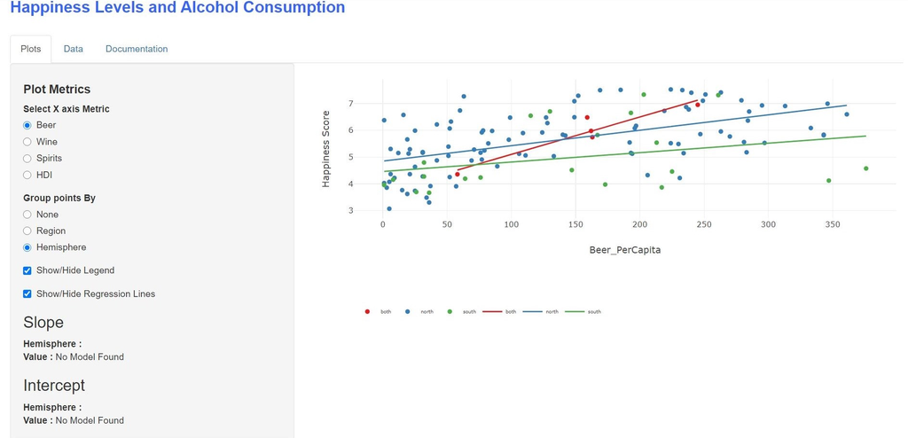

#### **5. Categorized Plot with** *Hover*

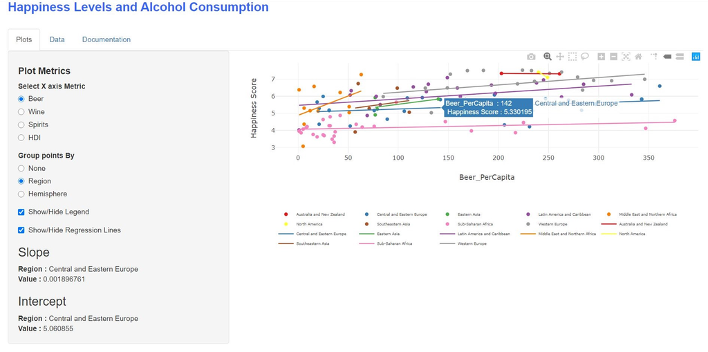